# Vignette 02b: Differences in paRsynth - Frequency Anchors’ Settings when Creating Vocal Identity Signals

GAJ

2024-12-02

In this vignette, we will go through how to create vocalization strings, convert them into Parsons code, calculate frequency anchors, and generate synthetic audio files using the paRsynth package for downstream bioacoustics analyses.

# Set Up Working Environment

Before using the functions in the paRsynth package, there are some preliminary steps we must go through to create a directory where different types of generated data can be automatically stored (audios and images). This automatic organization of generated data will make it easier to streamline the process of using paRsynth’s functions.

**Load packages and set path**

It is good practice to clean your global environment before using functions from open-sourced packages. In order for paRsynth functions to run, they need specific external R packages as well. For example, ‘write_audio’ generates and saves audio files in .wav format which requires the package `soundgen::soundgen()` to be installed and loaded.

```r
# Clean the global environment
rm(list = ls())

# Specify the required packages
X <- c("devtools", "dplyr", "stringdist", "tidyverse", "ggplot2", "apcluster", "soundgen", "parallel", "stringr", "data.table", "tuneR", "pbapply", "warbleR", "magrittr")

# Install the packages in X if not already installed
is_installed <- function(p) is.element(p, installed.packages()[,1])

invisible(lapply(1:length(X), function(x){
  if(!is_installed(X[x])){
    install.packages(X[x], repos = "http://lib.stat.cmu.edu/R/CRAN")
  }
}))

# Install the paRsynth package from GitHub if you haven't installed it already
# devtools::install_github("gsvidaurre/paRsynth")

# Add paRsynth to the list of packages to load
# X <- c(X, "paRsynth")

# Change "Desktop/.../GitHub_repos" based on where paRsynth is stored on your local machine
# testing_path <- "C://Users/summe/OneDrive/Desktop/github_repo/paRsynth/R/" # Summer's testing path
testing_path <- "~/Desktop/BIRDS/GitHub_repos/paRsynth/R" # Alexandra's testing path

# Load the paRsynth functions that will be tested below
source(file.path(testing_path, "generate_strings.R"))
source(file.path(testing_path, "parsons_code.R"))
source(file.path(testing_path, "frequency_anchors.R"))
source(file.path(testing_path, "write_audio.R"))

# Load all of the packages specified above
invisible(lapply(X, library, character.only = TRUE))
```

**Initialize working directories for data on your local machine**

It is important to have your files organized, especially when creating many different types of output data (audios and images). Therefore, initializing working directories in the beginning will be helpful in understanding the data you create with paRsynth and where they are stored.

```r
# Initialize a base path (this will need to be different per user)
# path <- "/Users/raneemsamman/Desktop" # Raneem's path
# path <- "/Users/gracesmith-vidaurre/Desktop" # Grace's path
path <- "/Users/gretheljuarez/Desktop/BIRDS/" # Alexandra's path
# path <- "/Users/summe/OneDrive/Desktop/" # Summer's path

# Initialize the directory for analysis on your local computer
analysis_dir <- "paRsynth_methods_synthetic_dataset_copy"

# Combine the base path and the newly created data directory into a single path
analysis_path <- file.path(path, analysis_dir)

# Create the data directory if it doesn't already exist on your computer
if(!dir.exists(analysis_path)){
  dir.create(analysis_path)
}

# Specify a folder inside the analysis directory where audio will be written out/read in
audio_dir <- "audio"

# Combine the base path, the analysis directory, and the audio directory into a single path
audio_path <- file.path(path, analysis_dir, audio_dir)

# Create the audio directory if it doesn't already exist on your computer
if(!dir.exists(audio_path)){
  dir.create(audio_path)
}

# Specify a folder inside the analysis directory where images will be written out/read in
images_dir <- "images"

# Combine the base path, the analysis directory, and the data directory into a single path
images_path <- file.path(path, analysis_dir, images_dir)

# Create the data directory if it doesn't already exist on your computer
if(!dir.exists(images_path)){
  dir.create(images_path)
}
```

**Check out documentation for the paRsynth functions. These functions are written below in the order in which they should be used**

Before using the paRsynth package, it would be beneficial for you to go over the description, usage, arguments, extra details, and examples of each function.

```r
?paRsynth::generate_strings
?paRsynth::parsons_code
?paRsynth::frequency_anchors
?paRsynth::write_audio
```

# paRsynth Workflow

**Step 1: Set parameters**

After installing paRsynth and loading the relevant libraries, you will be able to take the first step of setting the parameters of the synthetic bird calls you will generate with paRsynth.

```r
# Set the seed for reproducibility
set.seed(2)

# Initialize the values of group_information and individual_information, which correspond to the length of the string that will be allocated to encoding group membership or individual identity information
# Group information can outweigh individual information by a factor of at least 10 or higher
# Random variation should be at least half or more compared to individual information
factor_ratio <- 4
individual_information <- 4
group_information <- individual_information * factor_ratio
random_variation <- 2

# Initialize the values of the number of groups, individuals, calls, and string length
n_groups <- 2
n_individuals <- 5
n_calls <- 2

# The global_strings refers to the number of characters in the the head and tail shared among all calls in the dataset to bound the variation. Number input here is split in half and those amount of characters are allocated to head and tail of string
global_strings <- 4
string_length <- (group_information + individual_information) + global_strings
```

**Step 2: Create character strings representing vocal signals with more group membership information encoded within the call than individual identity information**

The second step is generating the character strings that represent vocalizations using the function generate_strings(). These strings encode both group membership (characters that are shared across individuals within a group) and individual identity (characters that are unique to each individual in a group). The function allows you to specify the length of the string as well as how much of the string encodes group versus individual identity information. It also allows you to control the number of groups, individuals in each group and calls per individual. These variables that you can control are known as the parameters of the function.

```r
### Generate the string for each call
calls <- generate_strings(
  n_groups = n_groups,
  n_individuals = n_individuals,
  n_calls = n_calls,
  string_length = string_length,
  group_information = group_information,
  individual_information = individual_information,
  random_variation = random_variation
  )

dplyr::glimpse(calls)
```

```
## Rows: 20
## Columns: 10
## $ Group             <int> 1, 1, 1, 1, 1, 1, 1, 1, 1, 1, 2, 2, 2, 2, 2, 2, 2, 2…
## $ Individual        <dbl> 1, 1, 2, 2, 3, 3, 4, 4, 5, 5, 1, 1, 2, 2, 3, 3, 4, 4…
## $ Call_ID           <dbl> 1, 2, 1, 2, 1, 2, 1, 2, 1, 2, 1, 2, 1, 2, 1, 2, 1, 2…
## $ Call              <chr> "ABBAAAAABBBBCBCCACBBCCCC", "ABBAAAAABBBBCCACACBBCCC…
## $ Global_head       <chr> "A", "A", "A", "A", "A", "A", "A", "A", "A", "A", "A…
## $ Group_head        <chr> "BBAAAAAB", "BBAAAAAB", "BBAAAAAB", "BBAAAAAB", "BBA…
## $ Individual_middle <chr> "BBBC", "BBBC", "CAAC", "CAAC", "ABAB", "ABAB", "CAB…
## $ Random_variation  <chr> "BC", "CA", "AB", "AB", "AC", "BB", "BB", "BC", "AA"…
## $ Group_tail        <chr> "CACBBCCC", "CACBBCCC", "CACBBCCC", "CACBBCCC", "CAC…
## $ Global_tail       <chr> "C", "C", "C", "C", "C", "C", "C", "C", "C", "C", "C…
```

The above chunk of code will generate a data frame called calls. Each row of the data frame represents a call, including the group, individual, and call identifiers, along with the vocalization string itself.

**Step 3: Convert strings to Parsons code**

```r
calls_parsons <- parsons_code(
  df = calls,
  string_col = "Call",
  global_head_col = "Global_head",
  group_head_col = "Group_head",
  individual_middle_col = "Individual_middle",
  random_variation_col = "Random_variation",
  group_tail_col = "Group_tail",
  global_tail_col = "Global_tail",
  mapping = list("A" = "up", "B" = "down", "C" = "constant")
)

glimpse(calls_parsons)
```

```
## Rows: 20
## Columns: 17
## $ Group                          <int> 1, 1, 1, 1, 1, 1, 1, 1, 1, 1, 2, 2, 2, …
## $ Individual                     <dbl> 1, 1, 2, 2, 3, 3, 4, 4, 5, 5, 1, 1, 2, …
## $ Call_ID                        <dbl> 1, 2, 1, 2, 1, 2, 1, 2, 1, 2, 1, 2, 1, …
## $ Call                           <chr> "ABBAAAAABBBBCBCCACBBCCCC", "ABBAAAAABB…
## $ Global_head                    <chr> "A", "A", "A", "A", "A", "A", "A", "A",…
## $ Group_head                     <chr> "BBAAAAAB", "BBAAAAAB", "BBAAAAAB", "BB…
## $ Individual_middle              <chr> "BBBC", "BBBC", "CAAC", "CAAC", "ABAB",…
## $ Random_variation               <chr> "BC", "CA", "AB", "AB", "AC", "BB", "BB…
## $ Group_tail                     <chr> "CACBBCCC", "CACBBCCC", "CACBBCCC", "CA…
## $ Global_tail                    <chr> "C", "C", "C", "C", "C", "C", "C", "C",…
## $ Call_Parsons_Code              <chr> "up-down-down-up-up-up-up-up-down-down-…
## $ Global_Head_Parsons_Code       <chr> "up", "up", "up", "up", "up", "up", "up…
## $ Group_Head_Parsons_Code        <chr> "down-down-up-up-up-up-up-down", "down-…
## $ Individual_Middle_Parsons_Code <chr> "down-down-down-constant", "down-down-d…
## $ Random_Variation_Parsons_Code  <chr> "down-constant", "constant-up", "up-dow…
## $ Group_Tail_Parsons_Code        <chr> "constant-up-constant-down-down-constan…
## $ Global_Tail_Parsons_Code       <chr> "constant", "constant", "constant", "co…
```

**Step 4: Convert the Parsons code to frequency values**

With the Parsons code in your data frame, you are now able to use the frequency_anchors() function to create frequency anchors that will guide the changes in pitch when creating synthetic audio files. Starting at a baseline frequency value, frequency values are calculated for each sequential character of the string using the Parsons code from the previous step. Therefore, the parameters of this function are the data frame with the parsons code, the names of the columns containing the parsons code (parsons_col), the numeric group identifiers (group_id_col), the numeric individual identifiers (individual_id_col), unique numeric identifiers for each vocalization per individual (call_id_col), the character string per vocalization (call_string_col), the baseline frequency value (starting_frequency) which has a default of 4000 Hz, and a value of frequency shift (frequency_shift) which has a default value of 1000.

**Example A**: section_transition = “continuous_trajectory”

```r
calls_parsons_frequencies_cf <- frequency_anchors(
  df = calls_parsons,
  parsons_col = "Call_Parsons_Code",
  group_id_col = "Group",
  individual_id_col = "Individual",
  call_id_col = "Call_ID",
  call_string_col = "Call",
  starting_frequency = 4000,
  frequency_shift = 1000,
  section_transition = "continuous_trajectory"
  )

glimpse(calls_parsons_frequencies_cf)
```

```
## Rows: 20
## Columns: 30
## $ Group        <int> 1, 1, 1, 1, 1, 1, 1, 1, 1, 1, 2, 2, 2, 2, 2, 2, 2, 2, 2, 2
## $ Individual   <dbl> 1, 1, 2, 2, 3, 3, 4, 4, 5, 5, 1, 1, 2, 2, 3, 3, 4, 4, 5, 5
## $ Call_ID      <dbl> 1, 2, 1, 2, 1, 2, 1, 2, 1, 2, 1, 2, 1, 2, 1, 2, 1, 2, 1, 2
## $ Call         <chr> "ABBAAAAABBBBCBCCACBBCCCC", "ABBAAAAABBBBCCACACBBCCCC", "…
## $ Parsons_Code <chr> "constant", "constant", "constant", "constant", "constant…
## $ Frequency1   <dbl> 4000, 4000, 4000, 4000, 4000, 4000, 4000, 4000, 4000, 400…
## $ Frequency2   <dbl> 5000, 5000, 5000, 5000, 5000, 5000, 5000, 5000, 5000, 500…
## $ Frequency3   <dbl> 4000, 4000, 4000, 4000, 4000, 4000, 4000, 4000, 4000, 400…
## $ Frequency4   <dbl> 3000, 3000, 3000, 3000, 3000, 3000, 3000, 3000, 3000, 300…
## $ Frequency5   <dbl> 4000, 4000, 4000, 4000, 4000, 4000, 4000, 4000, 4000, 400…
## $ Frequency6   <dbl> 5000, 5000, 5000, 5000, 5000, 5000, 5000, 5000, 5000, 500…
## $ Frequency7   <dbl> 6000, 6000, 6000, 6000, 6000, 6000, 6000, 6000, 6000, 600…
## $ Frequency8   <dbl> 7000, 7000, 7000, 7000, 7000, 7000, 7000, 7000, 7000, 700…
```

[output cut: 17 more lines]

**Example B**: section_transition = “starting_frequency”

```r
calls_parsons_frequencies_sf <- frequency_anchors(
  df = calls_parsons,
  parsons_col = "Call_Parsons_Code",
  group_id_col = "Group",
  individual_id_col = "Individual",
  call_id_col = "Call_ID",
  call_string_col = "Call",
  starting_frequency = 4000,
  frequency_shift = 1000,
  section_transition = "starting_frequency"
  )

glimpse(calls_parsons_frequencies_sf)
```

```
## Rows: 20
## Columns: 30
## $ Group        <int> 1, 1, 1, 1, 1, 1, 1, 1, 1, 1, 2, 2, 2, 2, 2, 2, 2, 2, 2, 2
## $ Individual   <dbl> 1, 1, 2, 2, 3, 3, 4, 4, 5, 5, 1, 1, 2, 2, 3, 3, 4, 4, 5, 5
## $ Call_ID      <dbl> 1, 2, 1, 2, 1, 2, 1, 2, 1, 2, 1, 2, 1, 2, 1, 2, 1, 2, 1, 2
## $ Call         <chr> "ABBAAAAABBBBCBCCACBBCCCC", "ABBAAAAABBBBCCACACBBCCCC", "…
## $ Parsons_Code <chr> "constant", "constant", "constant", "constant", "constant…
## $ Frequency1   <dbl> 4000, 4000, 4000, 4000, 4000, 4000, 4000, 4000, 4000, 400…
## $ Frequency2   <dbl> 5000, 5000, 5000, 5000, 5000, 5000, 5000, 5000, 5000, 500…
## $ Frequency3   <dbl> 3000, 3000, 3000, 3000, 3000, 3000, 3000, 3000, 3000, 300…
## $ Frequency4   <dbl> 2000, 2000, 2000, 2000, 2000, 2000, 2000, 2000, 2000, 200…
## $ Frequency5   <dbl> 3000, 3000, 3000, 3000, 3000, 3000, 3000, 3000, 3000, 300…
## $ Frequency6   <dbl> 4000, 4000, 4000, 4000, 4000, 4000, 4000, 4000, 4000, 400…
## $ Frequency7   <dbl> 5000, 5000, 5000, 5000, 5000, 5000, 5000, 5000, 5000, 500…
## $ Frequency8   <dbl> 6000, 6000, 6000, 6000, 6000, 6000, 6000, 6000, 6000, 600…
```

[output cut: 17 more lines]

This will return an updated data frame that includes all of the previous columns in addition to new columns that represent each frequency anchor for each vocalization (the number of columns added in this step corresponds to the character length of your vocalization string).

**Step 5: For each call or string, use these frequency anchor vectors to generate synthetic audio files with the soundgen package**

**Example A**

```r
synthetic_call_metadata1_cf <- write_audio(
  df = calls_parsons_frequencies_cf,
  sylLen = 400,
  sampling_rate = 150000,
  pitch_sampling_rate = 44100,
  smoothing = list(interpol = "loess", loessSpan = 1, discontThres = 0, jumpThres = 0),
  rolloffExact = c(0.25),
  formants = NA,
  vocalTract = NA,
  temperature = 0,
  vibratoFreq = 1,
  prefix = "A",
  save_path = audio_path,
  invalidArgAction = "ignore"
  )

glimpse(synthetic_call_metadata1_cf)
```

[output not shown]

**Example B**

```r
synthetic_call_metadata1_sf <- write_audio(
  df = calls_parsons_frequencies_sf,
  sylLen = 400,
  sampling_rate = 150000,
  pitch_sampling_rate = 44100,
  smoothing = list(interpol = "loess", loessSpan = 1, discontThres = 0, jumpThres = 0),
  rolloffExact = c(0.25),
  formants = NA,
  vocalTract = NA,
  temperature = 0,
  vibratoFreq = 1,
  prefix = "B",
  save_path = audio_path,
  invalidArgAction = "ignore"
  )

glimpse(synthetic_call_metadata1_sf)
```

[output not shown]

This will create files with the extension .wav for each vocalization and will save them in your desired and specified directory with a prefix of your preference.

**Step 6: Save the metadata for the synthetic audio files to a CSV file**

The data frames that you generate in R using paRsynth can be saved as physical files in your working directory. You can also save your paRsynth generated metadata into a CSV file. I recommend using this file type since it is compatible with R, Microsoft Word, and other software. You can use the function `write.csv()` to save data frames to .csv spreadsheets on your computer:

**Example A**

```r
# Add extra metadata for upcoming image files names and rearrange columns
synthetic_call_metadata1_cf %>%
  write.csv(., file = file.path(analysis_path, "synthetic_call_metadata1_cf.csv"), row.names = FALSE)
```

```r
synthetic_call_metadata1_cf_csv <- read.csv(file.path(analysis_path, "synthetic_call_metadata1_cf.csv"))

glimpse(synthetic_call_metadata1_cf_csv)
```

```
## Rows: 20
## Columns: 31
## $ Group           <int> 1, 1, 1, 1, 1, 1, 1, 1, 1, 1, 2, 2, 2, 2, 2, 2, 2, 2, …
## $ Individual      <int> 1, 1, 2, 2, 3, 3, 4, 4, 5, 5, 1, 1, 2, 2, 3, 3, 4, 4, …
## $ Call_ID         <int> 1, 2, 1, 2, 1, 2, 1, 2, 1, 2, 1, 2, 1, 2, 1, 2, 1, 2, …
## $ Call            <chr> "ABBAAAAABBBBCBCCACBBCCCC", "ABBAAAAABBBBCCACACBBCCCC"…
## $ Parsons_Code    <chr> "constant", "constant", "constant", "constant", "const…
## $ Frequency1      <int> 4000, 4000, 4000, 4000, 4000, 4000, 4000, 4000, 4000, …
## $ Frequency2      <int> 5000, 5000, 5000, 5000, 5000, 5000, 5000, 5000, 5000, …
## $ Frequency3      <int> 4000, 4000, 4000, 4000, 4000, 4000, 4000, 4000, 4000, …
## $ Frequency4      <int> 3000, 3000, 3000, 3000, 3000, 3000, 3000, 3000, 3000, …
## $ Frequency5      <int> 4000, 4000, 4000, 4000, 4000, 4000, 4000, 4000, 4000, …
## $ Frequency6      <int> 5000, 5000, 5000, 5000, 5000, 5000, 5000, 5000, 5000, …
## $ Frequency7      <int> 6000, 6000, 6000, 6000, 6000, 6000, 6000, 6000, 6000, …
## $ Frequency8      <int> 7000, 7000, 7000, 7000, 7000, 7000, 7000, 7000, 7000, …
```

[output cut: 18 more lines]

**Example B**

```r
# Add extra metadata for upcoming image files names and rearrange columns
synthetic_call_metadata1_sf %>%
  write.csv(., file = file.path(analysis_path, "synthetic_call_metadata1_sf.csv"), row.names = FALSE)
```

```r
synthetic_call_metadata1_sf_csv <- read.csv(file.path(analysis_path, "synthetic_call_metadata1_sf.csv"))

glimpse(synthetic_call_metadata1_sf_csv)
```

```
## Rows: 20
## Columns: 31
## $ Group           <int> 1, 1, 1, 1, 1, 1, 1, 1, 1, 1, 2, 2, 2, 2, 2, 2, 2, 2, …
## $ Individual      <int> 1, 1, 2, 2, 3, 3, 4, 4, 5, 5, 1, 1, 2, 2, 3, 3, 4, 4, …
## $ Call_ID         <int> 1, 2, 1, 2, 1, 2, 1, 2, 1, 2, 1, 2, 1, 2, 1, 2, 1, 2, …
## $ Call            <chr> "ABBAAAAABBBBCBCCACBBCCCC", "ABBAAAAABBBBCCACACBBCCCC"…
## $ Parsons_Code    <chr> "constant", "constant", "constant", "constant", "const…
## $ Frequency1      <int> 4000, 4000, 4000, 4000, 4000, 4000, 4000, 4000, 4000, …
## $ Frequency2      <int> 5000, 5000, 5000, 5000, 5000, 5000, 5000, 5000, 5000, …
## $ Frequency3      <int> 3000, 3000, 3000, 3000, 3000, 3000, 3000, 3000, 3000, …
## $ Frequency4      <int> 2000, 2000, 2000, 2000, 2000, 2000, 2000, 2000, 2000, …
## $ Frequency5      <int> 3000, 3000, 3000, 3000, 3000, 3000, 3000, 3000, 3000, …
## $ Frequency6      <int> 4000, 4000, 4000, 4000, 4000, 4000, 4000, 4000, 4000, …
## $ Frequency7      <int> 5000, 5000, 5000, 5000, 5000, 5000, 5000, 5000, 5000, …
## $ Frequency8      <int> 6000, 6000, 6000, 6000, 6000, 6000, 6000, 6000, 6000, …
```

[output cut: 18 more lines]

Now that you have generated your metadata with paRsyth and it has been saved as a CSV file, navigate to Vignette 03 Analysis to learn how to use the generated outputs of the package described above for downstream bioacoustics analysis.

```r
# Read the CSV file of each dataset
Example_A <- read.csv("/Users/gretheljuarez/Desktop/BIRDS/paRsynth_methods_synthetic_dataset_copy/synthetic_call_metadata1_cf.csv")
Example_B <- read.csv("/Users/gretheljuarez/Desktop/BIRDS/paRsynth_methods_synthetic_dataset_copy/synthetic_call_metadata1_sf.csv")

# Combine the CSV files of each dataset
synthetic_call_metadata_cf_sf <- rbind(Example_A, Example_B)

# Write out the CSV file containing both datasets
synthetic_call_metadata_cf_sf %>%
  write.csv(., file = file.path(analysis_path, "synthetic_call_metadata_cf_sf.csv"), row.names = FALSE)
```

```r
synthetic_call_metadata_cf_sf_csv <- read.csv(file.path(analysis_path, "synthetic_call_metadata_cf_sf.csv"))

glimpse(synthetic_call_metadata_cf_sf_csv)
```

```
## Rows: 40
## Columns: 31
## $ Group           <int> 1, 1, 1, 1, 1, 1, 1, 1, 1, 1, 2, 2, 2, 2, 2, 2, 2, 2, …
## $ Individual      <int> 1, 1, 2, 2, 3, 3, 4, 4, 5, 5, 1, 1, 2, 2, 3, 3, 4, 4, …
## $ Call_ID         <int> 1, 2, 1, 2, 1, 2, 1, 2, 1, 2, 1, 2, 1, 2, 1, 2, 1, 2, …
## $ Call            <chr> "ABBAAAAABBBBCBCCACBBCCCC", "ABBAAAAABBBBCCACACBBCCCC"…
## $ Parsons_Code    <chr> "constant", "constant", "constant", "constant", "const…
## $ Frequency1      <int> 4000, 4000, 4000, 4000, 4000, 4000, 4000, 4000, 4000, …
## $ Frequency2      <int> 5000, 5000, 5000, 5000, 5000, 5000, 5000, 5000, 5000, …
## $ Frequency3      <int> 4000, 4000, 4000, 4000, 4000, 4000, 4000, 4000, 4000, …
## $ Frequency4      <int> 3000, 3000, 3000, 3000, 3000, 3000, 3000, 3000, 3000, …
## $ Frequency5      <int> 4000, 4000, 4000, 4000, 4000, 4000, 4000, 4000, 4000, …
## $ Frequency6      <int> 5000, 5000, 5000, 5000, 5000, 5000, 5000, 5000, 5000, …
## $ Frequency7      <int> 6000, 6000, 6000, 6000, 6000, 6000, 6000, 6000, 6000, …
## $ Frequency8      <int> 7000, 7000, 7000, 7000, 7000, 7000, 7000, 7000, 7000, …
```

[output cut: 18 more lines]

# Bioacoustics Analysis Steps

**Step 1: Create a warbleR selection table**

To organize all the paRsynth generated outputs you created in the previous vignettes, you will have to create a warbleR selection table. The warbleR package is very useful to streamline bioacustics analysis. First you will list all the .wav files and then organize them in a selection table.

```r
# Create a vector of all of the audio files in the analysis path
wavs <- list.files(path = audio_path, pattern = ".wav$", full.names = FALSE)
length(wavs)
```

```
## [1] 40
```

```r
head(wavs)
```

```
## [1] "A_Group1_Indiv1_Call1.wav" "A_Group1_Indiv1_Call2.wav"
## [3] "A_Group1_Indiv2_Call1.wav" "A_Group1_Indiv2_Call2.wav"
## [5] "A_Group1_Indiv3_Call1.wav" "A_Group1_Indiv3_Call2.wav"
```

```r
tail(wavs)
```

```
## [1] "B_Group2_Indiv3_Call1.wav" "B_Group2_Indiv3_Call2.wav"
## [3] "B_Group2_Indiv4_Call1.wav" "B_Group2_Indiv4_Call2.wav"
## [5] "B_Group2_Indiv5_Call1.wav" "B_Group2_Indiv5_Call2.wav"
```

```r
# w <- 25 # testing

# Create a selection table including synthetic call metadata and its corresponding audio file name
sel_tbl <- data.table::rbindlist(lapply(1:length(wavs), function(w){

  tmp <- tuneR::readWave(file.path(audio_path, wavs[w]))

  # Return the metadata for the given call using the synthetic metadata generated during audio file generation above

  synthetic_call_metadata <- read.csv("/Users/gretheljuarez/Desktop/BIRDS/paRsynth_methods_synthetic_dataset_copy/synthetic_call_metadata_cf_sf.csv")

  metadats_tmp <- synthetic_call_metadata %>%
    dplyr::filter(grepl(wavs[w], audio_file_name))

  # glimpse(metadats_tmp)

  # Create a row for the selection table in warbleR format if the audio file exists and metadata for that file also exists
  if(nrow(metadats_tmp) > 0){

    # Use 0.1s as a margin to indicate where the vocalization starts and ends in the audio file
    # soundgen::soundgen() adds 100ms of silence before and after the synthetic vocalization by default
    res <- data.frame(
      sound.files = wavs[w],
      selec = 1,
      start = 0.1,
      end = seewave::duration(tmp) - 0.1,
      sampling_rate = tmp@samp.rate,
      group_ID = metadats_tmp[["Group"]],
      individual_ID = metadats_tmp[["Individual"]],
      call_ID = metadats_tmp[["Call"]]
    )

  } else {

    res <- data.frame(
      sound.files = wavs[w],
      selec = 1,
      start = 0.1,
      end = seewave::duration(tmp) + 0.1,
      sampling_rate = NA,
      group_ID = NA,
      individual_ID = NA,
      call_ID = NA
    )

  }

  return(res)

}))

# Check the selection table for all the unique sampling rates
unique(sel_tbl$sampling_rate)
```

```
## [1] 150000
```

```r
# See the selection table in warbleR format with all useful metadata for the synthetic experiment
glimpse(sel_tbl)
```

```
## Rows: 40
## Columns: 8
## $ sound.files   <chr> "A_Group1_Indiv1_Call1.wav", "A_Group1_Indiv1_Call2.wav"…
## $ selec         <dbl> 1, 1, 1, 1, 1, 1, 1, 1, 1, 1, 1, 1, 1, 1, 1, 1, 1, 1, 1,…
## $ start         <dbl> 0.1, 0.1, 0.1, 0.1, 0.1, 0.1, 0.1, 0.1, 0.1, 0.1, 0.1, 0…
## $ end           <dbl> 0.5209867, 0.5221467, 0.5428200, 0.5428200, 0.5316933, 0…
## $ sampling_rate <int> 150000, 150000, 150000, 150000, 150000, 150000, 150000, …
## $ group_ID      <int> 1, 1, 1, 1, 1, 1, 1, 1, 1, 1, 2, 2, 2, 2, 2, 2, 2, 2, 2,…
## $ individual_ID <int> 1, 1, 2, 2, 3, 3, 4, 4, 5, 5, 1, 1, 2, 2, 3, 3, 4, 4, 5,…
## $ call_ID       <chr> "ABBAAAAABBBBCBCCACBBCCCC", "ABBAAAAABBBBCCACACBBCCCC", …
```

This will output a neatly organized selection table of the uniquely generated vocalizations and their corresponding metadata.

**Step 2: Create spectrogram image files of each audio file**

Using the warbleR package, spectrogram images can be created from each synthetic vocalization you generated with paRsynth. Using a spectrogram is beneficial to analyze vocalizations because it provides precise information on frequency over time. First, you will use warbleR to create spectrograms of the generated vocalization in the selection table. Then you will rename the spectrogram image files saved in your images_path.

**Example A**

```r
# To make spectrograms of dataset 1 (more group info), you will need to filter it out from the selection table you made above.
A_sel_tbl <- sel_tbl %>%
    dplyr::filter(grepl("A", sound.files))

# Create spectrograms for filtered calls
warbleR::spectrograms(A_sel_tbl, wl = 512, flim = c(0, 12), wn = "hanning", pal = reverse.gray.colors.2,ovlp = 90, inner.mar = c(5, 4, 4, 2), outer.mar = c(0, 0, 0, 0), picsize = 1, res = 100, cexlab = 1, propwidth = FALSE, xl = 1, osci = FALSE, gr = FALSE, sc = FALSE, line = FALSE, mar = 0.05, it = "jpeg", parallel = 1, path = audio_path, pb = TRUE, fast.spec = FALSE, by.song = NULL, sel.labels = NULL, title.labels = NULL, dest.path = images_path, box = TRUE, axis = TRUE)

# Rename the image files
imgs <- list.files(images_path)

new_nms <- gsub(".wav-1", "", imgs)

invisible(file.rename(file.path(images_path, imgs), file.path(images_path, new_nms)))
```

**Example B**

```r
# To make spectrograms of dataset 1 (more group info), you will need to filter it out from the selection table you made above.
B_sel_tbl <- sel_tbl %>%
    dplyr::filter(grepl("B", sound.files))

# Create spectrograms for filtered calls
warbleR::spectrograms(B_sel_tbl, wl = 512, flim = c(0, 12), wn = "hanning", pal = reverse.gray.colors.2,ovlp = 90, inner.mar = c(5, 4, 4, 2), outer.mar = c(0, 0, 0, 0), picsize = 1, res = 100, cexlab = 1, propwidth = FALSE, xl = 1, osci = FALSE, gr = FALSE, sc = FALSE, line = FALSE, mar = 0.05, it = "jpeg", parallel = 1, path = audio_path, pb = TRUE, fast.spec = FALSE, by.song = NULL, sel.labels = NULL, title.labels = NULL, dest.path = images_path, box = TRUE, axis = TRUE)

# Rename the image files
imgs <- list.files(images_path)

new_nms <- gsub(".wav-1", "", imgs)

invisible(file.rename(file.path(images_path, imgs), file.path(images_path, new_nms)))
```

This will output appropriately named spectrograms for the synthetically generated vocalizations in the selection table created previously.

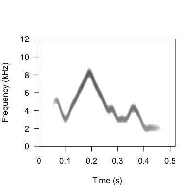

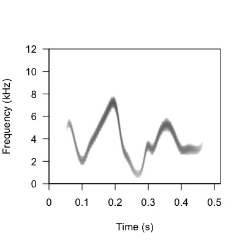

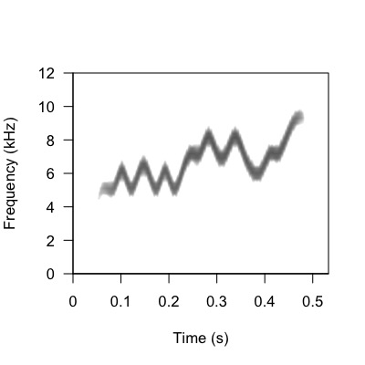

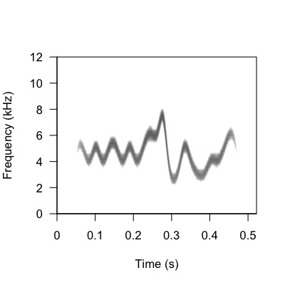